# Report of the Severe Weather impact in US’s health and economy

zhenyue zhu

May 8, 2016

## Synopsis

Storms and other severe weather events can cause both public health and economic problems for the world. They can result in fatalities, injuries, and property damage from 1950 to present. Thus it is crucial for us to understand what kind of events have the strongest effect for our health and economy.

This project involves exploring the U.S. National Oceanic and Atmospheric Administration’s (NOAA) storm database. This database tracks characteristics of major storms and weather events in the United States, including when and where they occur, as well as estimates of any fatalities, injuries, and property damage.

The purpose of this project is address the following questions:

- Across the United States, which types of events are most harmful with respect to population health?
- Across the United States, which types of events have the greatest economic consequences?

## Data Processing

First download the data from the website and then directly read the bz2 format file into the data set.

```r
library(ggplot2)
url="http://d396qusza40orc.cloudfront.net/repdata%2Fdata%2FStormData.csv.bz2"
download.file(url, destfile = "~/data/R/stormData.csv.bz2")
data<-read.csv("~/data/R/stormData.csv.bz2")
```

Get some basic information of this data set.

```r
dim(data)
```

```
## [1] 902297     37
```

```r
#head(data,n=10)
str(data)
```

```
## 'data.frame':    902297 obs. of  37 variables:
##  $ STATE__   : num  1 1 1 1 1 1 1 1 1 1 ...
##  $ BGN_DATE  : Factor w/ 16335 levels "1/1/1966 0:00:00",..: 6523 6523 4242 11116 2224 2224 2260 383 3980 3980 ...
##  $ BGN_TIME  : Factor w/ 3608 levels "00:00:00 AM",..: 272 287 2705 1683 2584 3186 242 1683 3186 3186 ...
##  $ TIME_ZONE : Factor w/ 22 levels "ADT","AKS","AST",..: 7 7 7 7 7 7 7 7 7 7 ...
##  $ COUNTY    : num  97 3 57 89 43 77 9 123 125 57 ...
##  $ COUNTYNAME: Factor w/ 29601 levels "","5NM E OF MACKINAC BRIDGE TO PRESQUE ISLE LT MI",..: 13513 1873 4598 10592 4372 10094 1973 23873 24418 4598 ...
##  $ STATE     : Factor w/ 72 levels "AK","AL","AM",..: 2 2 2 2 2 2 2 2 2 2 ...
##  $ EVTYPE    : Factor w/ 985 levels "   HIGH SURF ADVISORY",..: 834 834 834 834 834 834 834 834 834 834 ...
##  $ BGN_RANGE : num  0 0 0 0 0 0 0 0 0 0 ...
##  $ BGN_AZI   : Factor w/ 35 levels "","  N"," NW",..: 1 1 1 1 1 1 1 1 1 1 ...
##  $ BGN_LOCATI: Factor w/ 54429 levels ""," Christiansburg",..: 1 1 1 1 1 1 1 1 1 1 ...
##  $ END_DATE  : Factor w/ 6663 levels "","1/1/1993 0:00:00",..: 1 1 1 1 1 1 1 1 1 1 ...
##  $ END_TIME  : Factor w/ 3647 levels ""," 0900CST",..: 1 1 1 1 1 1 1 1 1 1 ...
##  $ COUNTY_END: num  0 0 0 0 0 0 0 0 0 0 ...
```

[output cut: 23 more lines]

```r
summary(data$EVTYPE)
```

```
##                     HAIL                TSTM WIND        THUNDERSTORM WIND
##                   288661                   219940                    82563
##                  TORNADO              FLASH FLOOD                    FLOOD
##                    60652                    54277                    25326
##       THUNDERSTORM WINDS                HIGH WIND                LIGHTNING
##                    20843                    20212                    15754
##               HEAVY SNOW               HEAVY RAIN             WINTER STORM
##                    15708                    11723                    11433
##           WINTER WEATHER             FUNNEL CLOUD         MARINE TSTM WIND
##                     7026                     6839                     6175
## MARINE THUNDERSTORM WIND               WATERSPOUT              STRONG WIND
##                     5812                     3796                     3566
##     URBAN/SML STREAM FLD                 WILDFIRE                 BLIZZARD
##                     3392                     2761                     2719
##                  DROUGHT                ICE STORM           EXCESSIVE HEAT
##                     2488                     2006                     1678
##               HIGH WINDS         WILD/FOREST FIRE             FROST/FREEZE
##                     1533                     1457                     1342
##                DENSE FOG       WINTER WEATHER/MIX           TSTM WIND/HAIL
##                     1293                     1104                     1028
##  EXTREME COLD/WIND CHILL                     HEAT                HIGH SURF
##                     1002                      767                      725
##           TROPICAL STORM           FLASH FLOODING             EXTREME COLD
##                      690                      682                      655
##            COASTAL FLOOD         LAKE-EFFECT SNOW        FLOOD/FLASH FLOOD
##                      650                      636                      624
##                LANDSLIDE                     SNOW          COLD/WIND CHILL
##                      600                      587                      539
##                      FOG              RIP CURRENT              MARINE HAIL
##                      538                      470                      442
##               DUST STORM                AVALANCHE                     WIND
##                      427                      386                      340
##             RIP CURRENTS              STORM SURGE            FREEZING RAIN
##                      304                      261                      250
##              URBAN FLOOD     HEAVY SURF/HIGH SURF        EXTREME WINDCHILL
##                      249                      228                      204
##             STRONG WINDS           DRY MICROBURST    ASTRONOMICAL LOW TIDE
##                      196                      186                      174
##                HURRICANE              RIVER FLOOD               LIGHT SNOW
##                      174                      173                      154
```

[output cut: 13 more lines]

```
##                       64                       61                       61
##      TROPICAL DEPRESSION                    SLEET         UNSEASONABLY DRY
##                       60                       59                       56
##                    FROST              GUSTY WINDS      THUNDERSTORM WINDSS
##                       53                       53                       51
##       MARINE STRONG WIND                    OTHER               SMALL HAIL
##                       48                       48                       47
##                   FUNNEL             FREEZING FOG             THUNDERSTORM
##                       46                       45                       45
##       Temperature record          TSTM WIND (G45)         Coastal Flooding
##                       43                       39                       38
##              WATERSPOUTS    MONTHLY PRECIPITATION                    WINDS
##                       37                       36                       36
##                  (Other)
##                     2940
```

```r
class(data$EVTYPE)
```

```
## [1] "factor"
```

As we can see that this event types has many things which have very similar names. For example, “THUNDERSTORM WIND” and “THUNDERSTORM WINDS” should be similar things. Then I will define the function which will make similar event types to be similar.

```r
reduce_cateory<-function(x){
  x <- tolower(x)
  if (grepl("hail", x)){
    return("hail")
  }
    if (grepl("flood|FLD|fld", x)){
    return("flood")
  }
  if (grepl("thunderstorm", x)){
    return("thunderstorm")
  }
  if (grepl("wind", x)){
    return("wind")
  }
  if (grepl("dry|drought", x)){
    return("dry weather")
  }
  if (grepl("heat|warm", x)){
    return("hot weather")
  }
  if (grepl("fire", x)){
    return("Fire")
  }
  if (grepl("rain", x)){
    return("rain")
  }
  if (grepl("hurricane|tropical|typhoon", x)){
    return("hurricane")
  }
  if (grepl("snow|ice|freez|blizzard|winter", x)){
    return("winter disaster")
  }
  else{
    return(x)
  }
}

events<-as.factor(sapply(data$EVTYPE,FUN=reduce_cateory))
summary(events)
```

```
##                   hail                   wind           thunderstorm
##                 290401                 254375                 109477
##                  flood                tornado        winter disaster
##                  86126                  60652                  43565
##              lightning                   rain           funnel cloud
##                  15754                  12197                   6844
##                   Fire             waterspout            hot weather
##                   4240                   3796                   2945
##            dry weather              dense fog              hurricane
##                   2813                   1293                   1055
##              high surf           extreme cold              landslide
##                    734                    657                    600
##                    fog            rip current             dust storm
##                    538                    470                    427
##              avalanche           rip currents            storm surge
##                    386                    304                    261
##   heavy surf/high surf  astronomical low tide             dust devil
##                    228                    174                    149
##       storm surge/tide astronomical high tide             wintry mix
##                    148                    103                     94
##          funnel clouds             heavy surf                   cold
##                     87                     87                     82
##            record cold                  sleet                  frost
##                     67                     59                     57
##                  other                 funnel                  glaze
##                     52                     46                     43
##     temperature record    mixed precipitation            waterspouts
##                     43                     37                     37
##  monthly precipitation              icy roads      unseasonably cold
##                     36                     32                     23
##           volcanic ash           prolong cold                 seiche
##                     23                     22                     21
##                tsunami             tornado f0       unseasonably wet
##                     20                     19                     19
##               mudslide     record temperature            sleet storm
##                     17                     16                     12
##      unseasonably cool                  smoke          coastal storm
##                     12                     11                     10
##            dense smoke           mixed precip       unseasonably hot
##                     10                     10                     10
```

[output cut: 13 more lines]

```
##                      5                      5                      5
##             wall cloud          beach erosion           blowing dust
##                      5                      4                      4
##        cold air funnel      cold temperatures           cold weather
##                      4                      4                      4
##              dam break    extreme/record cold     high surf advisory
##                      4                      4                      4
##    monthly temperature             record low             rough surf
##                      4                      4                      4
##           saharan dust             tornado f1              wet month
##                      4                      4                      4
##               wet year              cold wave    heavy precipitation
##                      4                      3                      3
##                (Other)
##                    252
```

Now We see that these event types are greatly reduced. The most common types are “hail”,“wind”,“thunderstorm”,“flood”,“tornado”,“winter disaster” and “lightning”. I will create the damage to the health and the damage to the crops.

## consider the events which has the most injuries or fatalities

Then I will sum the fatalties and injuries for these type events and create the total data frame.

```r
fatal <- aggregate(data$FATALITIES, list(events), sum)
injury <- aggregate(data$INJURIES, list(events), sum)
names(fatal) <- c("event", "count");
names(injury) <- c("event", "count")
health <- data.frame(fatal$event, fatal$count, injury$count)
names(health) <- c("event", "fatalities", "injuries")
health <- health[order(-health$injuries, -health$fatalities), ][1:10,]
health
```

```
##               event fatalities injuries
## 240         tornado       5633    91346
## 94      hot weather       3143     9228
## 290            wind       1212     8964
## 58            flood       1553     8683
## 291 winter disaster        638     5969
## 106       lightning        816     5230
## 239    thunderstorm        210     2478
## 95        hurricane        199     1716
## 55             Fire         90     1608
## 70             hail         45     1467
```

It’s very obvious from this table that the max fatalities type from 1950 to present is tornado related disasters. Similarly, the most injuries types are also related to tornados.

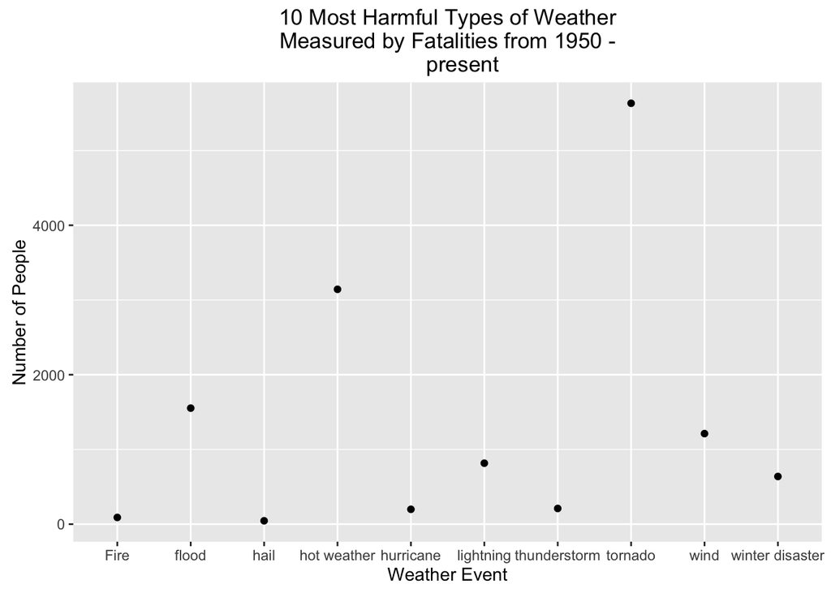

```r
library(ggplot2)
qplot(data = health, x = event, y = fatalities, geom = c("point", "smooth"))+
labs(title = '10 Most Harmful Types of Weather\n Measured by Fatalities from 1950 -
     present', y = 'Number of People', x = 'Weather Event')
```

## Consider the event which has the most influence on the economic consequences.

I need the columns with “PRODMG” and “CROPDMG”, since these columns have different units, I have to convert the units from k to 10^3, M to 10^6, etc…

```r
convert <- function(coeff, exp){
  if (is.na(exp)){
    as.numeric(coeff)
  }
  else if (toupper(exp)== "K"){
    as.numeric(coeff)*10^3
  }
  else if (toupper(exp) == "M"){
    as.numeric(coeff)*10^6
  }
  else if (toupper(exp)== "B"){
    as.numeric(coeff)*10^9
  }
  else{
    as.numeric(coeff)
  }
}

prop <- apply(data[, c('PROPDMG', 'PROPDMGEXP')], 1, function(x) convert(x['PROPDMG'], x['PROPDMGEXP']))
crop <- apply(data[, c('CROPDMG', 'CROPDMGEXP')], 1, function(x) convert(x['CROPDMG'], x['CROPDMGEXP']))
```

```r
prop_dmg <- aggregate(prop, list(events), sum)
crop_dmg <- aggregate(crop, list(events), sum)
names(prop_dmg) <- c("event", "cost");
names(crop_dmg) <- c("event", "cost")
economy <- data.frame(prop_dmg$event, prop_dmg$cost, crop_dmg$cost)
names(economy) <- c("event", "prop", "crop")
economy <- economy[order(-economy$prop, -economy$crop), ][1:10,]
economy
```

```
##                event         prop        crop
## 58             flood 167588050582 12388597200
## 95         hurricane  92972537560  6201013800
## 240          tornado  56937160779   414953270
## 170      storm surge  43323536000        5000
## 70              hail  17619991072  3114212873
## 291  winter disaster  12372195313  7200342400
## 290             wind  10867551118  1344487750
## 55              Fire   8501628500   403281630
## 239     thunderstorm   6430975459   652846388
## 171 storm surge/tide   4641188000      850000
```

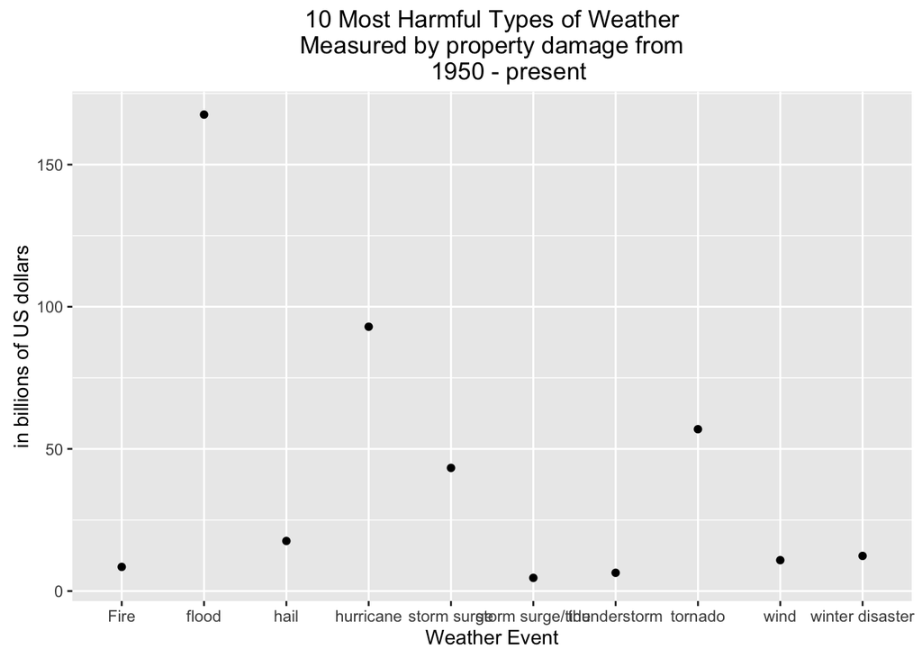

```r
library(ggplot2)
qplot(data = economy, x = event, y = prop/10^9, geom = c("point", "smooth"))+
labs(title = '10 Most Harmful Types of Weather\n Measured by property damage from
     1950 - present', y = 'in billions of US dollars', x = 'Weather Event')
```

It’s easy to see that flood has the highest both property and crop damage.

## Results and Conclusion.

- The most dangerous event type for the people’s health is **Tornado**.
- The most property and crop damage event type is **flood**.